# The Shape of Achievement: Modeling the Functional Form of Mathematics, Reading, and Science

This post contains the information in a handout presented at a roundtable at the 2022 AERA Conference.

William Murrah, Svetlanna Chesser and Natalie Neugebauer www.statistical-thinking.com (QMER)aub.ie/qmer  
2022-04-20

### Problem Statement

- A major goal in educational reform is to implement large-scale interventions to alleviate achievement disparities (Foderaro 2010).
- But to intervene, we first must better understand what social processes lead to these disparities (Reardon 2011).
- Often, researchers aiming at understanding educational achievement disparities compare a series of student level predictors of later achievement scores.
- The timing of the outcome varies, often between the end of kindergarten and fifth grade (Cameron et al. 2015; Juel 1988; Kendeou et al. 2009; Duncan et al. 2007; Grissmer et al. 2010).
- Because the timing of the achievement outcome has important implications for which skills are identified as important predictors of achievement (Cole and Maxwell 2003; Rioux and Little 2020), and because various skills underlying achievement develop differently (Paris 2005), there has been more recent emphasis on growth modeling of achievement scores (Cameron et al. 2015).
- Nonlinear growth models offer advantages to modeling growth in achievement, such as including multiple time point for achievement outcomes, modeling nonlinear trajectories, and the potential to extrapolate beyond time points measure in the data (but with great caution). **The purpose of this study was to determine the functional form of achievement, and use the three most commonly studied predictors of achievement, SES, race, and gender, to model differences in achievement trajectories.**

### Results

- We found evidence that the Gompertz curve was the best fitting functional model for mathematics, reading, and science achievement (replicating Cameron et al. 2015).
- We found differences across academic subjects in the estimated parameters of the growth curves.
- Consistently, the earlier the rapid growth, the higher the predicted attained level of achievement for the student.
- We found group differences, based primarily on SES and to a lesser extent between racial groups, on the timing of parameter and later level of achievement across subjects.
- Gaps consistently started before kindergarten entry and grew over time.

### Discussion and Implications

- Our findings replicate those of Cameron et al. (2015) that the Gompertz curve is the best fitting model for math and reading.
- We found that the Gompertz curve is also the best fit for science.
- The resulting model suggests that SES disparities are substantially greater than disparities estimated by racial groups, and need addressing.
- While it is more reasonable to extrapolate with functional nonlinear models, we should still be cautious about making inferences about early, preschool, achievement until we can validate such predictions with data during these crucial ages.
- Future work will need to decompose the proxy predictors of SES, race and gender, to determine which social and environmental resources are viable targets for early intervention.
- Nonlinear models provide an opportunity to integrate information across data sets, by making predictions outside of the range of modeled data.
- To better understand these disparities we need more longitudinal data in early childhood.

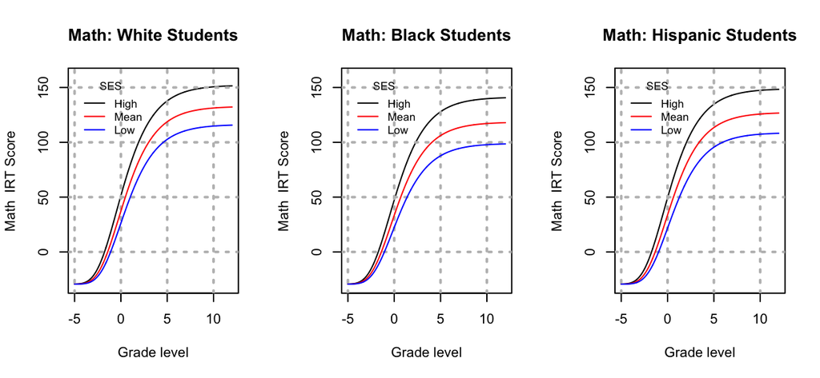

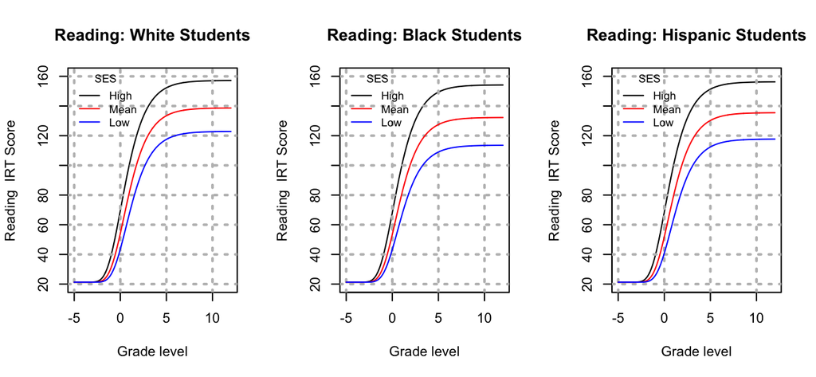

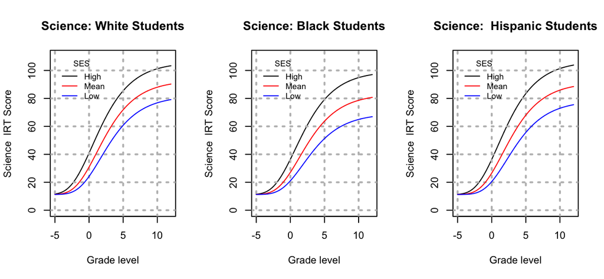

### References

Cameron, C. E., K. J. Grimm, J. S. Steele, L. Castro-Schilo, and D. W. Grissmer. 2015. “Nonlinear Gompertz Curve Models of Achievement Gaps in Mathematics and Reading.” *Journal of Educational Psychology* 107 (3): 789–804. https://doi.org/10.1037/edu0000009.

Cole, David A, and Scott E Maxwell. 2003. “Testing Mediational Models with Longitudinal Data: Questions and Tips in the Use of Structural Equation Modeling.” *Journal of Abnormal Psychology* 112 (4): 558.

Duncan, Greg J, Chantelle J Dowsett, Amy Claessens, Katherine Magnuson, Aletha C Huston, Pamela Klebanov, Linda S Pagani, et al. 2007. “School Readiness and Later Achievement.” *Developmental Psychology* 43 (6): 1428.

Foderaro, L. W. 2010. “Alternate Path for Teachers Gains Ground.” *New York Times* 6: 2010.

Grissmer, David, Kevin J Grimm, Sophie M Aiyer, William M Murrah, and Joel S Steele. 2010. “Fine Motor Skills and Early Comprehension of the World: Two New School Readiness Indicators.” *Developmental Psychology* 46 (5): 1008.

Juel, C. 1988. “Learning to Read and Write: A Longitudinal Study of 54 Children from First Through Fourth Grades.” *Journal of Educational Psychology* 80: 437–47. https://doi.org/10.1037/0022-0663.80.4.437.

Kendeou, Panayiota, Paul Van den Broek, Mary Jane White, and Julie S Lynch. 2009. “Predicting Reading Comprehension in Early Elementary School: The Independent Contributions of Oral Language and Decoding Skills.” *Journal of Educational Psychology* 101 (4): 765.

Paris, S. G. 2005. “Reinterpreting the Development of Reading Skills.” *Reading Research Quarterly* 40: 184–202. https://doi.org/10.1598/RRQ.40.2.3.

Reardon, S. F. 2011. *The Widening Academic Achievement Gap Between the Rich and the Poor: New Evidence and Possible Explanations*. In Whither opportunity: Russell Sage.

Rioux, Charlie, and Todd D Little. 2020. “Underused Methods in Developmental Science to Inform Policy and Practice.” *Child Development Perspectives* 14 (2): 97–103.